# Principle Component Analysis

Kim Pham

11/10/2017

## 0. Load libraries

```r
library(dplyr)
library(tidyr)
library(ggplot2)
library(corrplot)
library(corrgram)
```

## 1. Upload data file

Data file description: The data comes from the Assistments online intelligent tutoring system (https://www.assistments.org/). It describes students working through online math problems. Each student has the following data associated with them:

- id
- prior_prob_count: How many problems a student has answered in the system prior to this session
- prior_percent_correct: The percentage of problems a student has answered correctly prior to this session
- problems_attempted: The number of problems the student has attempted in the current session
- mean_correct: The average number of correct answers a student made on their first attempt at problems in the current session
- mean_hint: The average number of hints a student asked for in the current session
- mean_attempt: The average number of attempts a student took to answer a problem in the current session
- mean_confidence: The average confidence each student has in their ability to answer the problems in the current session

```r
df <- read.csv("Data/Assistments-confidence.csv")
df <- select(df, -id) # remove id
```

## 2. Explore coorelation between variables

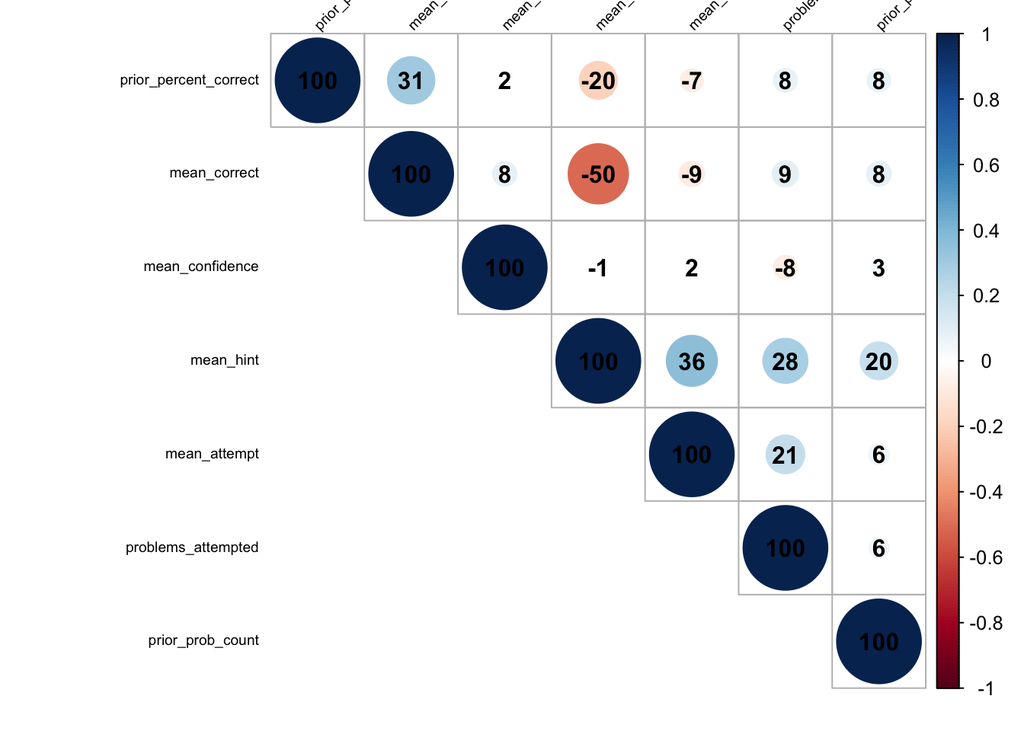

```r
COR <- cor(df) #coorelation matrix

# visualize coorelation matrix
corrplot(COR, order="AOE", method="circle", tl.pos="lt", type="upper",
tl.col="black", tl.cex=0.6, tl.srt=45,
        addCoef.col="black", addCoefasPercent = TRUE,
        sig.level=0.50, insig = "blank")
```

## 3. Process and structure data for PCA

```r
df2 <- select(df, -mean_correct) # remove mean_correct variable
df3 <- scale(df2, center = TRUE) # scale data
```

## 4. Run PCA on scaled data

```r
pca <- prcomp(df3, scale = TRUE)
```

princomp does not generate eigenvalues directly, but we can print a list of the standard deviation of the variance accounted for by each component.

```r
pca$sdev
```

```
## [1] 1.2825140 1.0543565 1.0245688 0.9621486 0.8556715 0.7320146
```

```r
pca$sdev^2
```

```
## [1] 1.6448423 1.1116675 1.0497412 0.9257299 0.7321737 0.5358454
```

```r
summary(pca) # pca summary gives the proportion of variance accounted for by each component
```

```
## Importance of components:
##                           PC1    PC2    PC3    PC4    PC5     PC6
## Standard deviation     1.2825 1.0544 1.0246 0.9621 0.8557 0.73201
## Proportion of Variance 0.2741 0.1853 0.1750 0.1543 0.1220 0.08931
## Cumulative Proportion  0.2741 0.4594 0.6344 0.7887 0.9107 1.00000
```

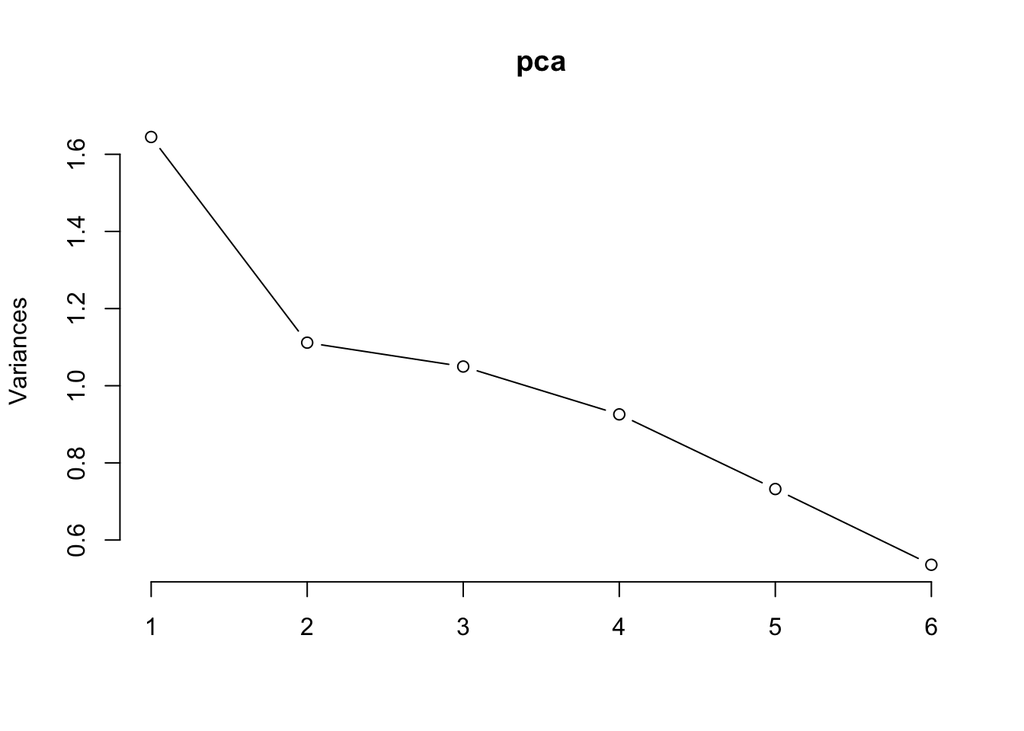

```r
plot(pca, type = "lines")
```

## 5. Analyze:

### Drop PCA components

We should consider dropping components 4-6 since they have the least amount of variances. The limitation is sometimes dropping components result in losing information. For example, if we drop PC4, we could lose useful information, since PC4 has some positive correlation to the mean_correct variable.

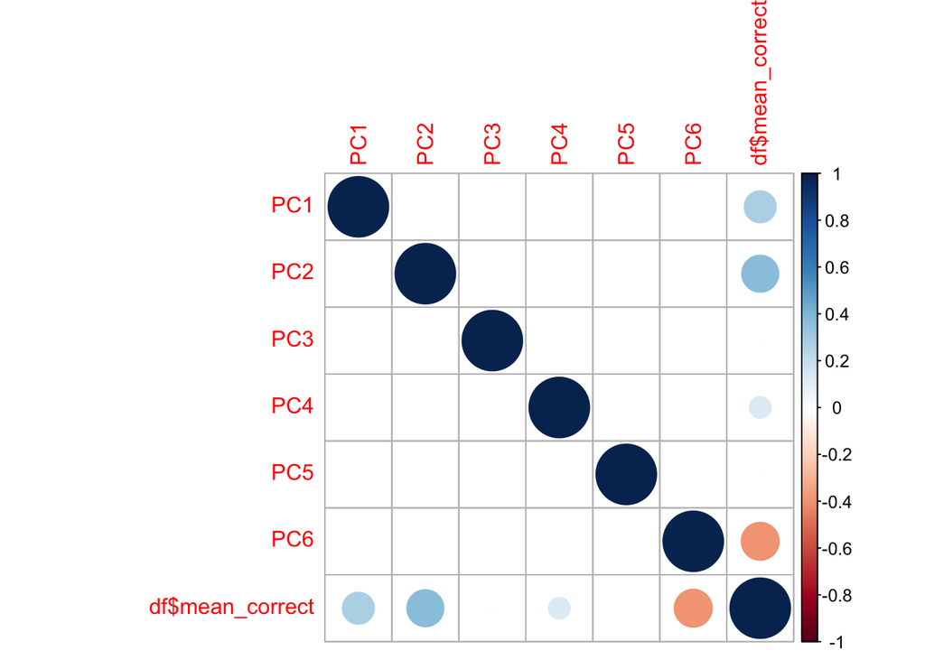

```r
df_pca <- as.data.frame(pca$x)
df_pca <- cbind(df_pca, as.data.frame(df$mean_correct))
COR2 <- cor(df_pca)
corrplot(COR2)
```

### Examine eigenvectors, or loadings

```r
pca$rotation # Eigenvalue = amount of variance/direction ... note: the bigger the eigenvalue, the better. e.g. if it’s 0, the transformation component is not good. It was bad. Maybe the data was hard to characterize.
```

```
##                               PC1         PC2         PC3        PC4
## prior_prob_count      -0.26034140  0.45818753 -0.40090679 -0.6897642
## prior_percent_correct  0.16840319  0.81617867  0.09267306  0.2640040
## problems_attempted    -0.45568733  0.31685183  0.36387724  0.3168141
## mean_hint             -0.63337594 -0.12501620 -0.08008842 -0.1122586
## mean_attempt          -0.54200011 -0.08510858 -0.04585364  0.3108682
## mean_confidence        0.03581325  0.02547483 -0.83051917  0.4948890
##                                PC5         PC6
## prior_prob_count      -0.007142834 -0.29280482
## prior_percent_correct  0.298843852  0.37134715
## problems_attempted    -0.592336569 -0.32911025
## mean_hint             -0.102302115  0.74412634
## mean_attempt           0.697232132 -0.33781385
## mean_confidence       -0.251357022 -0.01452143
```

```r
loadings <- abs(pca$rotation) # abs() will make all eigenvectors positive
sweep(loadings, 2, colSums(loadings), "/") #sweep() computes each row as a proportion of the column.
```

```
##                              PC1        PC2        PC3        PC4
## prior_prob_count      0.12423113 0.25081186 0.22101700 0.31516257
## prior_percent_correct 0.08035956 0.44677621 0.05108998 0.12062699
## problems_attempted    0.21744737 0.17344469 0.20060288 0.14475664
## mean_hint             0.30223780 0.06843387 0.04415217 0.05129246
## mean_attempt          0.25863458 0.04658844 0.02527878 0.14203987
## mean_confidence       0.01708956 0.01394492 0.45785919 0.22612148
##                               PC5        PC6
## prior_prob_count      0.003664468 0.14011651
## prior_percent_correct 0.153315014 0.17770154
## problems_attempted    0.303884750 0.15748983
## mean_hint             0.052483764 0.35608836
## mean_attempt          0.357699023 0.16165478
## mean_confidence       0.128952980 0.00694897
```

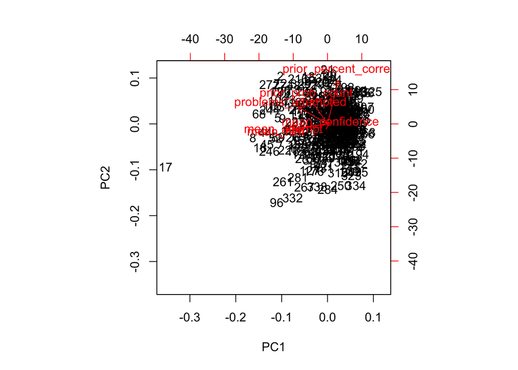

```r
biplot(pca) # plots data transformation by PC1 and PC2, where axes represent direction of maximum variance and original variable directions are mapped as red arrows; meant to answer which variables "go together" and represent the same underlying construct point in the same direction
```

- PC1: high variance for mean_hint, mean_atempt, and problems_attempted
- PC2: high variance for prior_percent_correct
- PC3: high variance for mean_confidence
- PC4: high variance for prior_prob_count
- PC5: high variance for mean_attempt and problems_attempted
- PC6: high variance for mean_hint

### Correlogram relationship of PC1 / PCA2 to mean_correct

[figure not shown]

```r
corrgram(df, order=TRUE,lower.panel=panel.shade,upper.panel=panel.pts,main="Assistments Online Behavior in PC2/PC1 Order")
```

## 1. Upload data file

Data file description: Data set from Rod Martin, Patricia Puhlik-Doris, Gwen Larsen, Jeanette Gray, Kelly Weir at the University of Western Ontario about people’s sense of humor.

```r
humor <- read.csv("Data/humor_data.csv")
```

## 2. Process and structure data for PCA

```r
humor <- scale(humor, center = TRUE)
```

## 3. Run PCA on scaled data

```r
pca <- prcomp(humor, scale = TRUE)
```

## 4. Analyze

### Drop PCA components

We should drop keep PCA components 1-5.

```r
pca$sdev
```

```
##  [1] 2.77741205 1.99741106 1.82727783 1.60136384 1.41994758 1.08471580
##  [7] 1.05831097 1.01722610 0.98473607 0.96930324 0.94652821 0.92110808
## [13] 0.90289108 0.88599396 0.86076682 0.84486247 0.83509363 0.79956676
## [19] 0.78074605 0.76943615 0.75814138 0.74351947 0.74010850 0.72710613
## [25] 0.71879884 0.70969332 0.69294580 0.68753963 0.65853463 0.65579228
## [31] 0.64351843 0.61413918 0.60177193 0.56000492 0.52627934 0.09014409
## [37] 0.04631333 0.04194096 0.03965788
```

```r
pca$sdev^2
```

```
##  [1] 7.714017706 3.989650939 3.338944253 2.564366147 2.016251126
##  [6] 1.176608357 1.120022107 1.034748940 0.969705120 0.939548776
## [11] 0.895915650 0.848440100 0.815212296 0.784985298 0.740919512
## [16] 0.713792588 0.697381379 0.639306999 0.609564388 0.592031995
## [21] 0.574778350 0.552821200 0.547760591 0.528683322 0.516671774
## [26] 0.503664605 0.480173888 0.472710740 0.433667859 0.430063512
## [31] 0.414115970 0.377166933 0.362129458 0.313605509 0.276969940
## [36] 0.008125957 0.002144925 0.001759044 0.001572748
```

```r
summary(pca)
```

```
## Importance of components:
##                           PC1    PC2     PC3     PC4    PC5     PC6
## Standard deviation     2.7774 1.9974 1.82728 1.60136 1.4199 1.08472
## Proportion of Variance 0.1978 0.1023 0.08561 0.06575 0.0517 0.03017
## Cumulative Proportion  0.1978 0.3001 0.38571 0.45146 0.5032 0.53333
##                            PC7     PC8     PC9    PC10    PC11    PC12
## Standard deviation     1.05831 1.01723 0.98474 0.96930 0.94653 0.92111
## Proportion of Variance 0.02872 0.02653 0.02486 0.02409 0.02297 0.02175
## Cumulative Proportion  0.56205 0.58858 0.61344 0.63753 0.66051 0.68226
##                          PC13    PC14   PC15   PC16    PC17    PC18
## Standard deviation     0.9029 0.88599 0.8608 0.8449 0.83509 0.79957
## Proportion of Variance 0.0209 0.02013 0.0190 0.0183 0.01788 0.01639
## Cumulative Proportion  0.7032 0.72329 0.7423 0.7606 0.77847 0.79487
##                           PC19    PC20    PC21    PC22    PC23    PC24
## Standard deviation     0.78075 0.76944 0.75814 0.74352 0.74011 0.72711
## Proportion of Variance 0.01563 0.01518 0.01474 0.01417 0.01405 0.01356
## Cumulative Proportion  0.81050 0.82568 0.84042 0.85459 0.86864 0.88219
##                           PC25    PC26    PC27    PC28    PC29    PC30
## Standard deviation     0.71880 0.70969 0.69295 0.68754 0.65853 0.65579
## Proportion of Variance 0.01325 0.01291 0.01231 0.01212 0.01112 0.01103
## Cumulative Proportion  0.89544 0.90835 0.92067 0.93279 0.94391 0.95493
##                           PC31    PC32    PC33    PC34   PC35    PC36
## Standard deviation     0.64352 0.61414 0.60177 0.56000 0.5263 0.09014
## Proportion of Variance 0.01062 0.00967 0.00929 0.00804 0.0071 0.00021
## Cumulative Proportion  0.96555 0.97522 0.98451 0.99255 0.9997 0.99986
##                           PC37    PC38    PC39
## Standard deviation     0.04631 0.04194 0.03966
## Proportion of Variance 0.00005 0.00005 0.00004
## Cumulative Proportion  0.99991 0.99996 1.00000
```

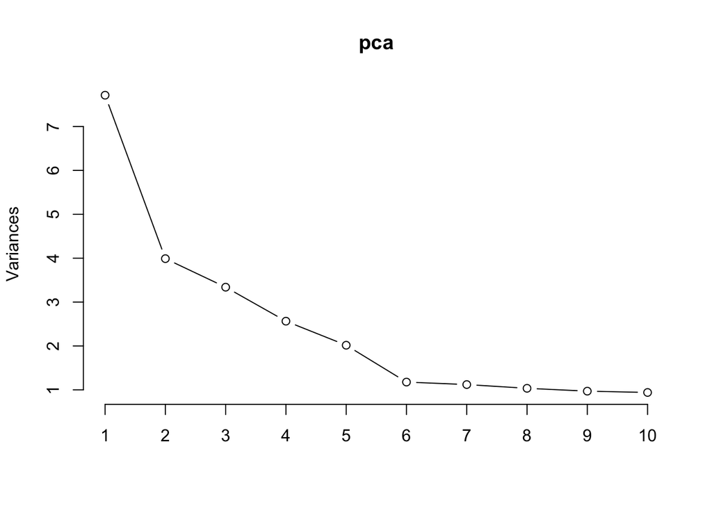

```r
plot(pca, type = "lines")
```

### Examine eigenvectors, or loadings

```r
pca$rotation
```

```
##                       PC1          PC2          PC3          PC4
## Q1             0.19779391 -0.142661624 -0.120542475  0.176352726
## Q2            -0.19174761  0.084914117 -0.132881557  0.152325047
## Q3            -0.14351692 -0.089896772  0.175995822  0.177299825
## Q4            -0.13290642 -0.283111667 -0.023482869 -0.107661920
## Q5            -0.21235309  0.120380974  0.057474498 -0.126277658
## Q6            -0.19040736  0.106616858 -0.089543365  0.087623709
## Q7             0.03309479  0.109148090 -0.251028461 -0.259573835
## Q8            -0.15941707 -0.291568725 -0.020049378 -0.128229328
## Q9             0.16266077 -0.081989795 -0.107525900  0.163484181
## Q10           -0.20769675  0.034808548 -0.190764327  0.180672050
## Q11           -0.07138205 -0.090151664  0.122091672  0.298060404
## Q12           -0.15745120 -0.239383682 -0.000424753 -0.183965724
## Q13           -0.19881917  0.142618777  0.047934944 -0.128037646
## Q14           -0.21419226  0.108557862 -0.160356301  0.124995925
## Q15            0.08109500  0.070488230 -0.341685713 -0.215826544
## Q16            0.11556960  0.180143417 -0.137950809  0.101898269
## Q17            0.20367498 -0.156201793 -0.160144714  0.189148454
## Q18           -0.18710563  0.041896904 -0.223261633  0.211561175
## Q19           -0.18020107 -0.064441979  0.080998686  0.169535741
## Q20           -0.13691760 -0.331733909  0.005963333 -0.081717317
## Q21           -0.20085025  0.108124603 -0.037703731 -0.171189967
## Q22            0.10220050 -0.077662016 -0.053716017 -0.070285845
## Q23            0.08030697 -0.001146785 -0.284869592 -0.172508833
## Q24           -0.07381897 -0.271414087 -0.110360877 -0.045084801
## Q25            0.18290021 -0.190355262 -0.126794958  0.175438765
## Q26           -0.21041518  0.065388177 -0.197066411  0.132487927
## Q27           -0.08657703 -0.100133596  0.138629765  0.251006304
## Q28           -0.17303805 -0.121348936 -0.026041902  0.045487963
## Q29            0.13246595 -0.202421255 -0.197345560  0.089166858
## Q30           -0.12169876  0.084949734 -0.185959763  0.188538636
## Q31            0.07136161  0.021533001 -0.353455499 -0.222160392
## Q32           -0.17433791 -0.264298748 -0.026188038 -0.132264379
## affiliative   -0.27643327  0.211322265  0.149100023 -0.225745296
## selfenhancing -0.26231008  0.096904787 -0.260480244  0.218368495
## agressive     -0.07221918 -0.050649989 -0.260342255  0.005487559
## selfdefeating -0.20640867 -0.369181272 -0.066325637 -0.125876573
## age           -0.00348121  0.024235207 -0.007514577 -0.009634547
## gender         0.04026800  0.050532117 -0.126334138 -0.057792913
## accuracy      -0.07133652  0.083333270 -0.054265824  0.022171163
```

[output cut: 345 more lines]

```
## Q25           -0.0445207338  0.1239014099  0.0355002900
## Q26           -0.1058421883 -0.0147384906 -0.1258539359
## Q27            0.1763926637  0.0415460313 -0.0218644557
## Q28           -0.0774149700 -0.0797593686  0.1497429217
## Q29           -0.0593379611  0.1710642926  0.0462578267
## Q30           -0.1071737743 -0.0129543819 -0.1194868228
## Q31            0.1837074861  0.0429448255 -0.0212825105
## Q32           -0.0708050744 -0.0763817024  0.1402578498
## affiliative   -0.2810618258  0.8020864343  0.2169990698
## selfenhancing  0.4889588377  0.0725295319  0.5602319834
## agressive     -0.4536322210 -0.1072276157  0.0537346178
## selfdefeating  0.2963961871  0.3152106295 -0.5902685958
## age            0.0008322489 -0.0006813795 -0.0016432195
## gender         0.0009833627  0.0006804494 -0.0010109775
## accuracy       0.0043370417 -0.0012122636 -0.0003701529
```

```r
loadings <- abs(pca$rotation[,1:5])
sweep(loadings, 2, colSums(loadings))
```

```
##                     PC1       PC2       PC3       PC4       PC5
## Q1            -5.522638 -5.022989 -4.992054 -5.448592 -4.721781
## Q2            -5.528684 -5.080736 -4.979714 -5.472620 -4.571414
## Q3            -5.576915 -5.075754 -4.936600 -5.447645 -4.572864
## Q4            -5.587525 -4.882539 -5.089113 -5.517283 -4.678268
## Q5            -5.508078 -5.045270 -5.055122 -5.498667 -4.583397
## Q6            -5.530024 -5.059034 -5.023053 -5.537321 -4.731883
## Q7            -5.687337 -5.056502 -4.861568 -5.365371 -4.722540
## Q8            -5.561014 -4.874082 -5.092547 -5.496715 -4.676599
## Q9            -5.557771 -5.083661 -5.005070 -5.461461 -4.697503
## Q10           -5.512735 -5.130842 -4.921832 -5.444273 -4.566161
## Q11           -5.649050 -5.075499 -4.990504 -5.326884 -4.448946
## Q12           -5.562980 -4.926267 -5.112171 -5.440979 -4.672356
## Q13           -5.521612 -5.023032 -5.064661 -5.496907 -4.667206
## Q14           -5.506239 -5.057093 -4.952240 -5.499949 -4.626798
## Q15           -5.639337 -5.095162 -4.770910 -5.409118 -4.636608
## Q16           -5.604862 -4.985507 -4.974645 -5.523046 -4.508984
## Q17           -5.516757 -5.009449 -4.952451 -5.435796 -4.709618
## Q18           -5.533326 -5.123754 -4.889334 -5.413384 -4.608020
## Q19           -5.540230 -5.101209 -5.031597 -5.455409 -4.464697
## Q20           -5.583514 -4.833917 -5.106633 -5.543227 -4.705775
## Q21           -5.519581 -5.057526 -5.074892 -5.453755 -4.612179
## Q22           -5.618231 -5.087988 -5.058880 -5.554659 -4.490601
## Q23           -5.640125 -5.164504 -4.827726 -5.452436 -4.546051
## Q24           -5.646613 -4.894236 -5.002235 -5.579860 -4.712452
## Q25           -5.537531 -4.975295 -4.985801 -5.449506 -4.688098
## Q26           -5.510016 -5.100262 -4.915530 -5.492457 -4.681775
## Q27           -5.633855 -5.065517 -4.973966 -5.373938 -4.465597
## Q28           -5.547393 -5.044302 -5.086554 -5.579457 -4.621113
## Q29           -5.587966 -4.963229 -4.915250 -5.535778 -4.659569
## Q30           -5.598733 -5.080701 -4.926636 -5.436406 -4.730015
## Q31           -5.649070 -5.144117 -4.759141 -5.402784 -4.686115
## Q32           -5.546094 -4.901352 -5.086408 -5.492680 -4.702383
## affiliative   -5.443998 -4.954328 -4.963496 -5.399199 -4.668796
## selfenhancing -5.458121 -5.068746 -4.852116 -5.406576 -4.635291
## agressive     -5.648212 -5.115001 -4.852254 -5.619457 -4.218861
## selfdefeating -5.514023 -4.796469 -5.046270 -5.499068 -4.736008
## age           -5.716950 -5.141415 -5.105081 -5.615310 -4.656120
## gender        -5.680164 -5.115118 -4.986262 -5.567152 -4.744702
## accuracy      -5.649095 -5.082317 -5.058330 -5.602774 -4.600456
```

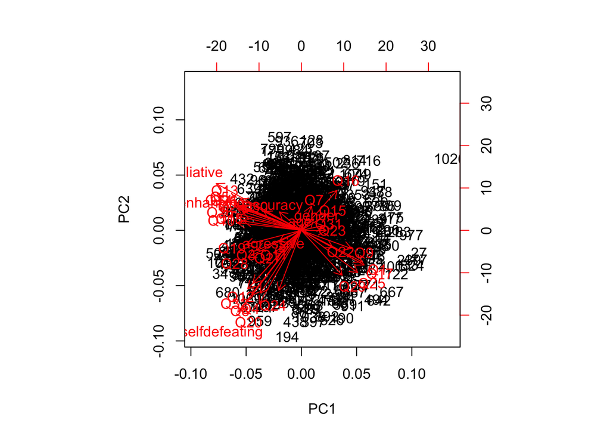

```r
biplot(pca)
```

Hard to read biplot and the loadings between the components are very similar. We should investigate other methods to interpret the components and its relationship to the original data.